# Term Project of BDA 507

### 2.2. Gender Distribution

- Female Male Population Average for each year both for Turkey and World.

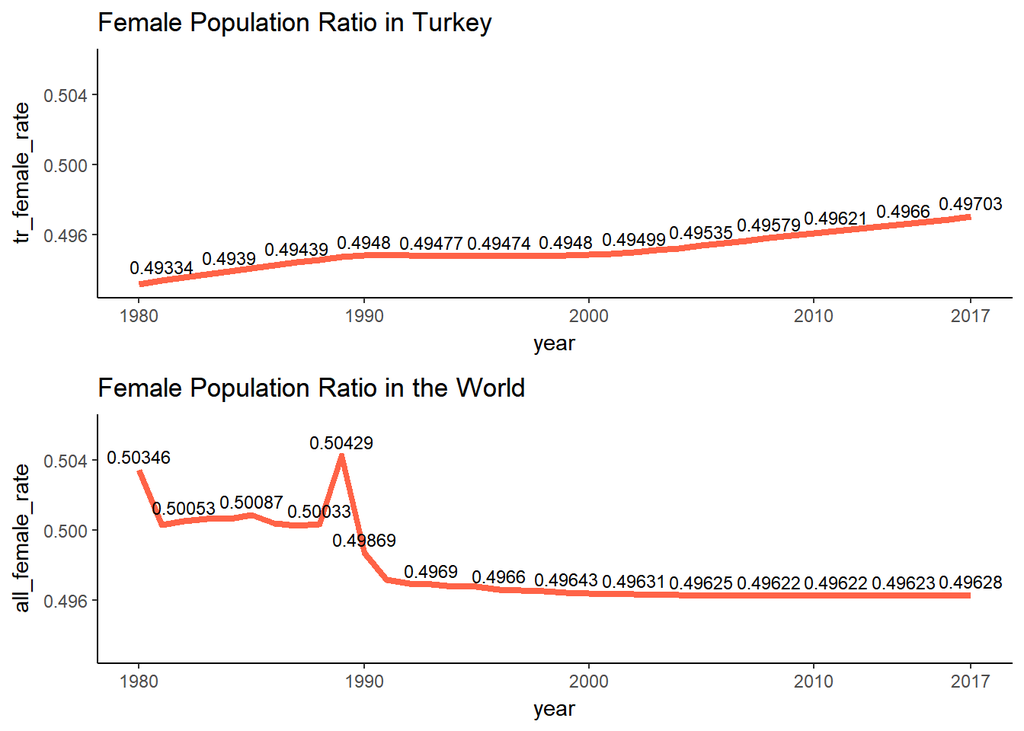

```r
query.sex_aveg_population <-dbGetQuery(con,"WITH TR AS
                (
                   SELECT
                   YEAR,
                   SUM(POPULATION) AS POPULATION_TOT_TR,
                   SUM(CASE WHEN SEX = 'Male' THEN POPULATION END) AS POPULATION_MALE_TR,
                   SUM(CASE WHEN SEX = 'Female' THEN POPULATION END) AS POPULATION_FEMALE_TR
                   FROM
                   POPULATION_AGE_SUMMARY
                   WHERE COUNTRY_CODE = 'TU'
                   GROUP BY YEAR
                ),
                ALLS AS
                (
                   SELECT
                   YEAR,
                   SUM(POPULATION)/COUNT(DISTINCT COUNTRY_CODE) AS POPULATION_TOT_ALL,
                   SUM(CASE WHEN SEX = 'Male' THEN POPULATION END)/COUNT(DISTINCT COUNTRY_CODE) AS POPULATION_MALE_ALL,
                   SUM(CASE WHEN SEX = 'Female' THEN POPULATION END)/COUNT(DISTINCT COUNTRY_CODE) AS POPULATION_FEMALE_ALL
                   FROM
                   POPULATION_AGE_SUMMARY
                   GROUP BY YEAR
                )
                SELECT
                TR.YEAR,
                POPULATION_TOT_TR,
                POPULATION_MALE_TR,
                POPULATION_FEMALE_TR,
                POPULATION_TOT_ALL,
                POPULATION_MALE_ALL,
                POPULATION_FEMALE_ALL
                FROM TR
                JOIN ALLS ON TR.YEAR = ALLS.YEAR
                ORDER BY TR.YEAR DESC")

new <- query.sex_aveg_population%>% mutate(tr_male_rate = round(population_male_tr/population_tot_tr,5),
                                          tr_female_rate =round(population_female_tr/population_tot_tr,5),
                                          all_male_rate = round(population_male_all/population_tot_all,5),
                                          all_female_rate = round(population_female_all/population_tot_all,5))


g0 <- ggplot(new,aes(x=year,y=tr_female_rate)) + geom_line(size=1.5,color=c("tomato")) +
      scale_y_continuous(limits=c(0.493,0.506)) +
      scale_x_continuous(breaks = c(1980,1990,2000,2010,2017)) +
      ggtitle("Female Population Ratio in Turkey") + theme_classic() +
      geom_text(aes(label = tr_female_rate),color = "black", size = 3,vjust = -0.5, nudge_y = 0,check_overlap = TRUE)

g1 <- ggplot(new,aes(x=year,y=all_female_rate)) + geom_line(size=1.5,color=c("tomato")) +
      scale_x_continuous(breaks = c(1980,1990,2000,2010,2017)) +
      scale_y_continuous(limits=c(0.493,0.506)) +
      ggtitle("Female Population Ratio in the World") + theme_classic() +
      geom_text(aes(label = all_female_rate),color = "black", size = 3,vjust = -0.5, nudge_y = 0,check_overlap = TRUE)

grid.arrange(g0,g1,nrow=2)
```

- When we examine the above graphs; although there is rise on female population year to year in Turkey, It is always near to 49% without any pick point.However, when we look at World graph, it is clearly declining but there is a pick point near to 1990. **Also on previous section; we saw there is a pick point on birth/death rate so we can conclude that near to 1990, there was an explosion on birth of females.**

### 2.3. Age Distribution

- Create a new table with age category to categorize population according to age segments:

```r
is_exist <- dbExistsTable(con, "POPULATION_AGE_SUMMARY")
is_exist
```

```
## [1] FALSE
```

```r
if(is_exist==FALSE){
  dbGetQuery(con,"CREATE TABLE POPULATION_AGE_SUMMARY AS
  SELECT
  YEAR,
  COUNTRY_CODE,
  AGE,
  CASE
  WHEN AGE <= 20 THEN '00 - 20'
  WHEN AGE <= 40 THEN '21 - 40'
  WHEN AGE <= 60 THEN '41 - 60'
  WHEN AGE <= 80 THEN '61 - 80'
  WHEN AGE <= 100 THEN '81 - 100' END AGE_CATEGORY,
  POPULATION,
  SEX
  FROM
  MIDYEAR_POPULATION_AGE_COUNTRY_CODE
  WHERE YEAR <= 2017
  ORDER BY AGE"
  )
}
```

```r
query.population.age.summary<-dbGetQuery(con,"SELECT *
                                         FROM POPULATION_AGE_SUMMARY"
                                  )

query.population.age.summary %>%
  head(5) %>%
  kable()
```

| year | country_code | age | age_category | population | sex |
| --- | --- | --- | --- | --- | --- |
| 1995 | TI | 0 | 00 - 20 | 78309 | Female |
| 2014 | GT | 0 | 00 - 20 | 186902 | Male |
| 2017 | MD | 0 | 00 - 20 | 19465 | Female |
| 2003 | BU | 0 | 00 - 20 | 31928 | Female |
| 1992 | GR | 0 | 00 - 20 | 53117 | Male |

- Find population distribution and rates among the age categories with DB query:

```r
query.avg_population <-dbGetQuery(con,"WITH TR AS
                          (
                            SELECT
                            YEAR,
                            SUM(CASE WHEN AGE_CATEGORY = '00 - 20' THEN POPULATION ELSE 0 END) AS TR_00_20_POPULATION,
                            SUM(CASE WHEN AGE_CATEGORY = '21 - 40' THEN POPULATION ELSE 0 END) AS TR_21_40_POPULATION,
                            SUM(CASE WHEN AGE_CATEGORY = '41 - 60' THEN POPULATION ELSE 0 END) AS TR_41_60_POPULATION,
                            SUM(CASE WHEN AGE_CATEGORY = '61 - 80' THEN POPULATION ELSE 0 END) AS TR_61_80_POPULATION,
                            SUM(CASE WHEN AGE_CATEGORY = '81 - 100' THEN POPULATION ELSE 0 END) AS TR_81_100_POPULATION,
                            SUM(POPULATION) AS POPULATION_TR
                            FROM
                            POPULATION_AGE_SUMMARY
                            WHERE COUNTRY_CODE = 'TU'
                            GROUP BY YEAR
                          ),
                          ALLS AS
                          (
                            SELECT
                            YEAR,
                            SUM(CASE WHEN AGE_CATEGORY = '00 - 20' THEN POPULATION ELSE 0 END)/COUNT(DISTINCT COUNTRY_CODE) AS ALL_00_20_POPULATION,
                            SUM(CASE WHEN AGE_CATEGORY = '21 - 40' THEN POPULATION ELSE 0 END)/COUNT(DISTINCT COUNTRY_CODE) AS ALL_21_40_POPULATION,
                            SUM(CASE WHEN AGE_CATEGORY = '41 - 60' THEN POPULATION ELSE 0 END)/COUNT(DISTINCT COUNTRY_CODE) AS ALL_41_60_POPULATION,
                            SUM(CASE WHEN AGE_CATEGORY = '61 - 80' THEN POPULATION ELSE 0 END)/COUNT(DISTINCT COUNTRY_CODE) AS ALL_61_80_POPULATION,
                            SUM(CASE WHEN AGE_CATEGORY = '81 - 100' THEN POPULATION ELSE 0 END)/COUNT(DISTINCT COUNTRY_CODE) AS ALL_81_100_POPULATION,
                            SUM(POPULATION)/COUNT(DISTINCT COUNTRY_CODE) AS POPULATION_ALL   FROM
                            POPULATION_AGE_SUMMARY
                            GROUP BY YEAR
                          )
                          SELECT
                          TR.YEAR,
                          TR_00_20_POPULATION,
                          TR_21_40_POPULATION,
                          TR_41_60_POPULATION,
                          TR_61_80_POPULATION,
                          TR_81_100_POPULATION,
                          POPULATION_TR,
                          ALL_00_20_POPULATION,
                          ALL_21_40_POPULATION,
                          ALL_41_60_POPULATION,
                          ALL_61_80_POPULATION,
                          ALL_81_100_POPULATION,
                          POPULATION_ALL FROM TR
                          JOIN ALLS ON TR.YEAR = ALLS.YEAR
                          ORDER BY TR.YEAR DESC")

new <- query.avg_population %>% mutate(tr_0_20_rate = round(tr_00_20_population /population_tr,3),
                                       all_0_20_rate = round(all_00_20_population /population_all,3))

head(new,5) %>% select(year,tr_00_20_population,all_00_20_population,tr_0_20_rate,all_0_20_rate) %>%
  kable()
```

| year | tr_00_20_population | all_00_20_population | tr_0_20_rate | all_0_20_rate |
| --- | --- | --- | --- | --- |
| 2017 | 27854340 | 11319384 | 0.345 | 0.349 |
| 2016 | 28032636 | 11283905 | 0.349 | 0.351 |
| 2015 | 28060856 | 11251746 | 0.353 | 0.354 |
| 2014 | 28001071 | 11221935 | 0.357 | 0.357 |
| 2013 | 27937543 | 11194079 | 0.361 | 0.360 |

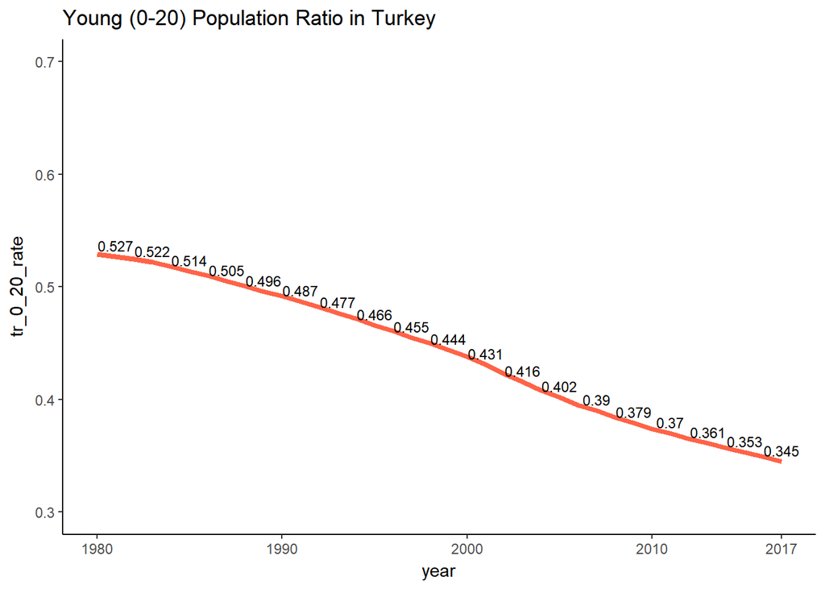

```r
g0 <- ggplot(new,aes(x=year,y=tr_0_20_rate)) + geom_line(size=1.5,color=c("tomato")) +
      scale_y_continuous(limits=c(0.30,0.70)) +
      scale_x_continuous(breaks = c(1980,1990,2000,2010,2017)) +
      ggtitle("Young (0-20) Population Ratio in Turkey") + theme_classic() +
      geom_text(aes(label = tr_0_20_rate),color = "black", size = 3,vjust = -0.5, nudge_y = 0,check_overlap = TRUE)
g1 <- ggplot(new,aes(x=year,y=all_0_20_rate)) + geom_line(size=1.5,color=c("tomato")) +
      scale_x_continuous(breaks = c(1980,1990,2000,2010,2017)) +
      scale_y_continuous(limits=c(0.30,0.70)) +
      ggtitle("Young(0-20) Population Ratio in the World") + theme_classic() +
      geom_text(aes(label = tr_0_20_rate),color = "black", size = 3,vjust = -0.5, nudge_y = 0,check_overlap = TRUE)

g0
```